# Best K for clustering

# Density plot

```r
ggplot(df_bootstrap_result, aes(silh, colour = K,fill=K)) + geom_density(alpha = 0.2)+geom_hdi(aes(color=K),lineend="round",size=2,credible_mass=0.95,alpha=0.8)+ggtitle("Silhouette result : Bootstrap on input data") +xlab("Silhouette")

ggplot(df_bootstrap_result_dunn, aes(dunn, colour = K,fill=K)) + geom_density(alpha = 0.2)+geom_hdi(aes(color=K),lineend="round",size=2,credible_mass=0.95,alpha=0.8)+ggtitle("Dunn result : Bootstrap on input data")+xlab("Dunn")
```

[output not shown]

# Confidence interval

```r
print(paste0("Confidence interval for K= 3 :",quantile(df_bootstrap_result[df_bootstrap_result$K=="K3",1], prob =0.025 ), " and ",quantile(df_bootstrap_result[df_bootstrap_result$K=="K3",1], prob =0.975 )))


 # Conclusion : 95 % sure sil with K =3 is somewhere in between 0.1641727 and 0.2102882

print(paste0("Confidence interval for K= 4 :",quantile(df_bootstrap_result[df_bootstrap_result$K=="K4",1], prob =0.025 ), " and ",quantile(df_bootstrap_result[df_bootstrap_result$K=="K4",1], prob =0.975 )))

 # Conclusion : 95 % sure sil with K =4 is somewhere in between 0.1445827  and 0.2136525

 print(paste0("Confidence interval for K= 8 :",quantile(df_bootstrap_result[df_bootstrap_result$K=="K8",1], prob =0.025 ), " and ",quantile(df_bootstrap_result[df_bootstrap_result$K=="K8",1], prob =0.975 )))

  # Conclusion : 95 % sure sil with K =8 is somewhere in between 0.1585761  and 0.2134542

 print(paste0("Confidence interval for K= 9 :",quantile(df_bootstrap_result[df_bootstrap_result$K=="K9",1], prob =0.025 ), " and ",quantile(df_bootstrap_result[df_bootstrap_result$K=="K9",1], prob =0.975 )))

 # Conclusion : 95 % sure sil with K =9 is somewhere in between 0.1668284  and 0.2115129
```

```r
print(paste0("Dunn index "))
print(paste0("Confidence interval for K= 3 :",quantile(df_bootstrap_result_dunn[df_bootstrap_result_dunn$K=="K3",1], prob =0.025 ), " and ",quantile(df_bootstrap_result_dunn[df_bootstrap_result_dunn$K=="K3",1], prob =0.975 )))

 # Conclusion : 95 % sure dunn with K =3 is somewhere in between 0.1127085  and 0.1864212

print(paste0("Confidence interval for K= 4  :",quantile(df_bootstrap_result_dunn[df_bootstrap_result_dunn$K=="K4",1], prob =0.025 ), " and ",quantile(df_bootstrap_result_dunn[df_bootstrap_result_dunn$K=="K4",1], prob =0.975 )))

 # Conclusion : 95 % sure dunn with K =4 is somewhere in between 0.1169171   and 0.1890072

 print(paste0("Confidence interval for K= 8  :",quantile(df_bootstrap_result_dunn[df_bootstrap_result_dunn$K=="K8",1], prob =0.025 ), " and ",quantile(df_bootstrap_result_dunn[df_bootstrap_result_dunn$K=="K8",1], prob =0.975 )))

  # Conclusion : 95 % sure dunn with K =8 is somewhere in between 0.1233294   and 0.2043868

 print(paste0("Confidence interval for K= 9  :",quantile(df_bootstrap_result_dunn[df_bootstrap_result_dunn$K=="K9",1], prob =0.025 ), " and ",quantile(df_bootstrap_result_dunn[df_bootstrap_result_dunn$K=="K9",1], prob =0.975 )))

 # Conclusion : 95 % sure dunn with K =9 is somewhere in between 0.1233294   and 0.2152493
```

# Bootstrap on prototype

- Sample input was provided to generate SOM code vector using SOM Brero model.
- Bootstrap sampling was done on prototype/code vector.
- Sample size = 16*16=256
- iterations=100 and Total time taken was approximately 7 mins.
- K means was used for clustering as SOM Brero superclass method does not work with matrix it need brero object.
- Final results are stored in csv.

```r
scaled_FS1_data_T0# = scale(scaled_FS1_T0)
 temp_FS1_T0_Brero <- trainSOM(x.data = scaled_FS1_data_T0, nb.save=2,
                               dimension = c(h_dimension_T,h_dimension_T),
                               radius.type=as.character(h_radius.type_T),
                               dist.type=as.character(h_dist.type_T),
                               maxit=95000,
                               eps0=h_eps_0_T,
                               init.proto=as.character(h_init.proto_T),
                               scaling =as.character(h_scaling_T))

 dim(temp_FS1_T0_Brero$prototypes)
# set.seed(2020) # used K means as sampling on the prototype and superclass of brero does not work
 for(i in 1:100){
   print(paste("Row ", i))
   temp_index = sample(1:256, 256, replace = TRUE)
   rescale_df <- temp_FS1_T0_Brero$prototypes[temp_index,] #scaled_data #

   # k =3
   km <- kmeans(rescale_df, 3)
   #Check silhoette
   temp_sil_p <- silhouette(km$cluster, dist(rescale_df))
   temp_sil_val_p<-fviz_silhouette(temp_sil_p)
   silh_stored_3_p[i]=mean(temp_sil_val_p$data$sil_width)
   #library(fpc)

   temp_clu_stats_p <- cluster.stats(dist(rescale_df),  km$cluster)
   dunn_stored_3_p[i]=temp_clu_stats_p$dunn


   # k =4
   km <- kmeans(rescale_df, 4)
   #Check silhoette
   temp_sil_p <- silhouette(km$cluster, dist(rescale_df))
   temp_sil_val_p<-fviz_silhouette(temp_sil_p)
   silh_stored_4_p[i]=mean(temp_sil_val_p$data$sil_width)
   #library(fpc)

   temp_clu_stats_p <- cluster.stats(dist(rescale_df),  km$cluster)
   dunn_stored_4_p[i]=temp_clu_stats_p$dunn



   # k =8
   km <- kmeans(rescale_df, 8)
   #Check silhoette
   temp_sil_p <- silhouette(km$cluster, dist(rescale_df))
   temp_sil_val_p<-fviz_silhouette(temp_sil_p)
   silh_stored_8_p[i]=mean(temp_sil_val_p$data$sil_width)
   #library(fpc)

   temp_clu_stats_p <- cluster.stats(dist(rescale_df),  km$cluster)
   dunn_stored_8_p[i]=temp_clu_stats_p$dunn


   # k =9
   km <- kmeans(rescale_df, 9)
   #Check silhoette
   temp_sil_p <- silhouette(km$cluster, dist(rescale_df))
   temp_sil_val_p<-fviz_silhouette(temp_sil_p)
   silh_stored_9_p[i]=mean(temp_sil_val_p$data$sil_width)
   #library(fpc)

   temp_clu_stats_p <- cluster.stats(dist(rescale_df),  km$cluster)
   dunn_stored_9_p[i]=temp_clu_stats_p$dunn


 }
 #df_sil_p : dataframe that stores results for all K values and corresponding silhoette acquired from bootstrap
#df_dunn_p : dataframe that stores results for all K values and corresponding dunn values acquired from bootstrap

 #write.table(df_sil_p, "D:\\Fs1_sil_100itr_bootstrap_onPrototype.csv", sep=",", row.names=FALSE, quote=FALSE)
 #write.table(df_dunn_p, "D:\\Fs1_dunn_100itr_bootstrap_onPrototype.csv", sep=",", row.names=FALSE, quote=FALSE)
 #--------------------------------------------------------------------------#
```

```r
df_sil_p<- read.csv("D:\\DKE\\Thesis_related\\Implementation\\Hyper_tuning_results\\Fs1_sil_100itr_bootstrap_onPrototype.csv")
df_dunn_p<- read.csv("D:\\DKE\\Thesis_related\\Implementation\\Hyper_tuning_results\\Fs1_dunn_100itr_bootstrap_onPrototype.csv")
head(df_sil_p)
head(df_dunn_p)
```

# Graph

- For Dunn and silhoette

```r
ggplot(df_sil_p, aes(silh, colour = K,fill=K))+geom_histogram()
```

[output not shown]

```r
ggplot(df_sil_p, aes(silh, colour = K,fill=K)) + geom_density(alpha = 0.2)+geom_hdi(aes(color=K),lineend="round",size=2,credible_mass=0.95,alpha=0.8)+ggtitle("Silhouette result : Bootstrap on prototye / code vectors") +xlab("Silhouette")

 ggplot(df_dunn_p, aes(dunn, colour = K,fill=K)) + geom_density(alpha = 0.2)+geom_hdi(aes(color=K),lineend="round",size=2,credible_mass=0.95,alpha=0.8)+ggtitle("Dunn result :Bootstrap on prototye / code vectors") +xlab("Dunn")
```

[output not shown]

# Confidence interval

```r
print(paste0("Silhouette "))
 print(paste0("Confidence interval for K= 3 :",quantile(df_sil_p[df_sil_p$K=="K3",1], prob =0.025 ), " and ",quantile(df_sil_p[df_sil_p$K=="K3",1], prob =0.975 )))

 # Conclusion : 95 % sure sil with K =3 is somewhere in between 0.2126651 and 0.2577378

 print(paste0("Confidence interval for K= 4 :",quantile(df_sil_p[df_sil_p$K=="K4",1], prob =0.025 ), " and ",quantile(df_sil_p[df_sil_p$K=="K4",1], prob =0.975 )))

 # Conclusion : 95 % sure sil with K =4 is somewhere in between 0.1796355   and 0.2586166

 print(paste0("Confidence interval for K= 8 :",quantile(df_sil_p[df_sil_p$K=="K8",1], prob =0.025 ), " and ",quantile(df_sil_p[df_sil_p$K=="K8",1], prob =0.975 )))

 # Conclusion : 95 % sure sil with K =8 is somewhere in between 0.2018807   and 0.261169

 print(paste0("Confidence interval for K= 9 :",quantile(df_sil_p[df_sil_p$K=="K9",1], prob =0.025 ), " and ",quantile(df_sil_p[df_sil_p$K=="K9",1], prob =0.975 )))

 # Conclusion : 95 % sure sil with K =9 is somewhere in between 0.2088765 and 0.2614842

 print(paste0("Dunn index values"))

 print(paste0("Confidence interval for K= 3 :",quantile(df_dunn_p[df_dunn_p$K=="K3",1], prob =0.025 ), " and ",quantile(df_dunn_p[df_dunn_p$K=="K3",1], prob =0.975 )))

 # Conclusion : 95 % sure dunn with K =3 is somewhere in between 0.09960056  and 0.1873531

 print(paste0("Confidence interval for K= 4 :",quantile(df_dunn_p[df_dunn_p$K=="K4",1], prob =0.025 ), " and ",quantile(df_dunn_p[df_dunn_p$K=="K4",1], prob =0.975 )))

 # Conclusion : 95 % sure dunn with K =4 is somewhere in between 0.100042    and 0.1912225

 print(paste0("Confidence interval for K= 8 :",quantile(df_dunn_p[df_dunn_p$K=="K8",1], prob =0.025 ), " and ",quantile(df_dunn_p[df_dunn_p$K=="K8",1], prob =0.975 )))

 # Conclusion : 95 % sure dunn with K =8 is somewhere in between 0.126386    and 0.1921703

 print(paste0("Confidence interval for K= 9 :",quantile(df_dunn_p[df_dunn_p$K=="K9",1], prob =0.025 ), " and ",quantile(df_dunn_p[df_dunn_p$K=="K9",1], prob =0.975 )))

 # Conclusion : 95 % sure dunn with K =9 is somewhere in between 0.1137588 and 0.1868615
```

# Confidence interval related

- The confidence interval describes the uncertainty inherent in this estimate and helps to visualize statistical test.
- CI describes a range of values within which we can be reasonably sure that the true effect actually lies.
- If the confidence interval is relatively narrow (e.g. 0.70 to 0.80), the effect size is known precisely.
- If the interval is wider (e.g. 0.60 to 0.93) the uncertainty is greater, although there may still be enough precision to make decisions about the utility of the intervention.
- Intervals that are very wide (e.g. 0.50 to 1.10) indicate that we have little knowledge about the effect, and that further information is needed.

# Conclusion:

- As per the analysis using bootstrap sampling, K=8 and 9 has the best results.

# Bootstrap on prototype for big range of K

- To understand the impact in depth, K= [2:15] will be studied along with bootstrap sampling.
- Reason to select this range is as, AIC and BIC check has min values in this range and it penalizes complex models.

```r
for(i in 1:500){
   print(paste("----Row ", i))
   temp_index = sample(1:256, 256, replace = TRUE)
   rescale_df <- FS1_T0_Brero$prototypes[temp_index,] #scaled_data #

  # results_list = list()

   for (temp_K in 2:15) {
     print(paste("temp_K ", temp_K))
     km <- kmeans(x = rescale_df, temp_K)

     #AIC and BIC check
     temp_df_k <- information_criteron_functn(km)


     #Check silhoette
     temp_sil_p <- silhouette(km$cluster, dist(rescale_df))
     temp_sil_val_p<-fviz_silhouette(temp_sil_p)
     temp_silh_stored_p=mean(temp_sil_val_p$data$sil_width)
     #library(fpc)

     temp_clu_stats_p <- cluster.stats(dist(rescale_df),  km$cluster)
     temp_dunn_stored_p=temp_clu_stats_p$dunn

     result_dat <- data.frame("Silhouette"=temp_silh_stored_p,"Dunn"=temp_silh_stored_p,
                              "AIC"=temp_df_k$AIC,
                              "BIC"=temp_df_k$BIC,
                              "K"=paste0("K",temp_K))


     df_boot_p_500 <- rbind(df_boot_p_500,result_dat)
   }

}

#Store results
#write.table(df_boot_p_500, "D:\\Fs1_dunn_silh_AIC_BIC500itr_bootstrap_onPrototype.csv", sep=",", row.names=FALSE, quote=FALSE)
```

```r
#--------------------------------------------------------------------------#
#   Generate graphs
#--------------------------------------------------------------------------#
df_graph<-df_boot_p_500
## Substring.. to remove K
for (i in 1: nrow(df_graph)) {
  df_graph$K[[i]]=substring(df_graph$K[[i]],2)
}
```

# Results

*Graph 1* : AIC values for different K * AIC values ranges from 2000 till 3200.  
* Optimal K is chosen which has min AIC value.  
* Low AIC value aproximately near 2400 had K= [4..12].  
* Count indicator shows that approximetly 150 times K= [10..14] had low values of AIC.  
* COunt indicator shows that approximetly 125 times K =[4,5,6,7,8] had low values of AIC.

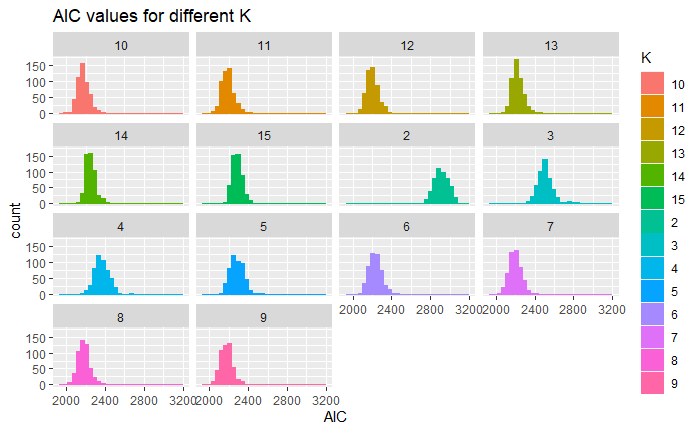

```r
ggplot(df_graph, aes(AIC, colour = K,fill=K))+geom_histogram()+ facet_wrap(~K)+ labs(title = "AIC values for different K")
```

*Graph 2* : BIC values for different K * BIC values ranges from 3000 to 4500.  
* BIC penalises more to complex models.  
* Low BIC values were approximetly near 3500.  
* Count indicator shows that approximetly 150 times K= [2] had low values of BIC.  
* COunt indicator shows that approximetly 200 times K =[3..10] had low values of BIC. Among these K=[3..7] had BIC below 3500

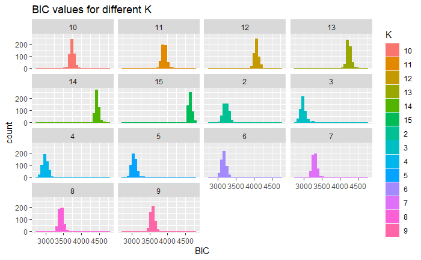

```r
ggplot(df_graph, aes(BIC, colour = K,fill=K))+geom_histogram()+ facet_wrap(~K)+ labs(title = "BIC values for different K")
```

*Graph 3* : Silhouette values for different K * shows histogram of Silhouette values for all Ks.  
* Silhouette ranges in between 0.15 to 0.35.  
* Silhouette value close to one indicates better clustering result.

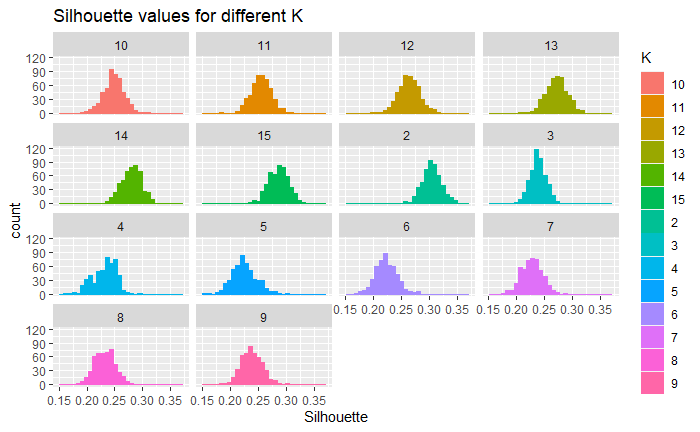

```r
ggplot(df_graph, aes(Silhouette, colour = K,fill=K))+geom_histogram()+ facet_wrap(~K) + labs(title = "Silhouette values for different K")
```

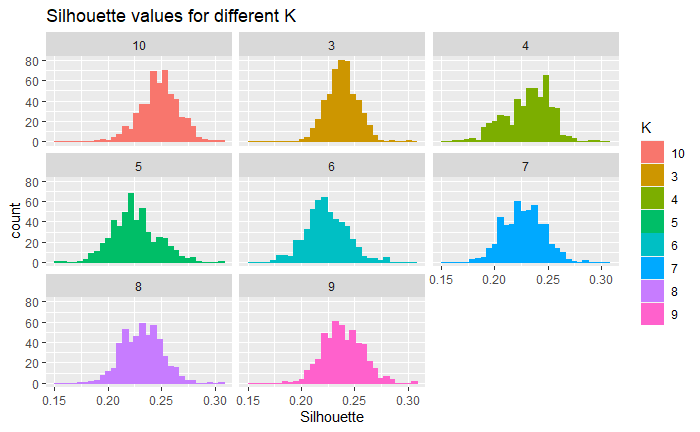

```r
df_graph %>% filter(between(K,3,10))%>% ggplot(aes(Silhouette, colour = K,fill=K))+geom_histogram()+ facet_wrap(~K) + labs(title = "Silhouette values for different K")
```

*Graph 4* : Dunn values for different K * Dunn values range from 0.08 to 0.22 approximately.

```
There were 17 warnings (use warnings() to see them)
```

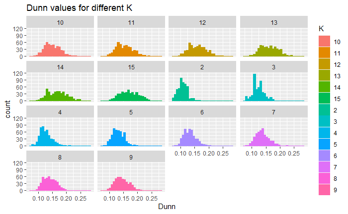

```r
ggplot(df_graph, aes(Dunn, colour = K,fill=K))+geom_histogram()+ facet_wrap(~K) + labs(title = "Dunn values for different K")
```

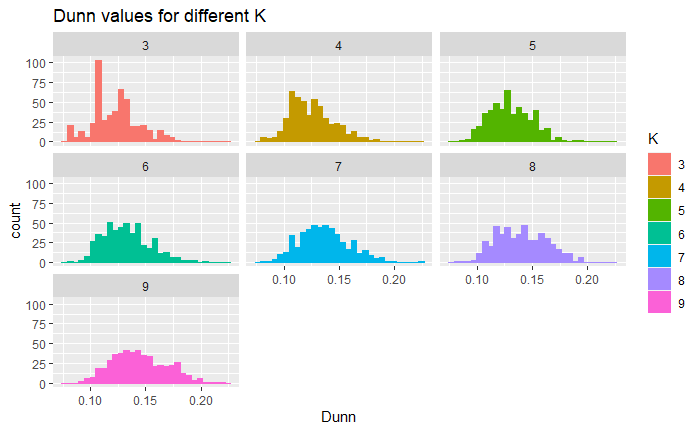

```r
df_graph %>% filter(between(K,3,9)) %>% ggplot( aes(Dunn, colour = K,fill=K))+geom_histogram()+ facet_wrap(~K) + labs(title = "Dunn values for different K")
```

# Box plot

- To compare across all K values, box plot was used.
- K values are filtered. BIC computation was given higher weightage in this selection.
- From the below plot its clear that, complex model is penalised more. Hence lets consider K range from [2..9]

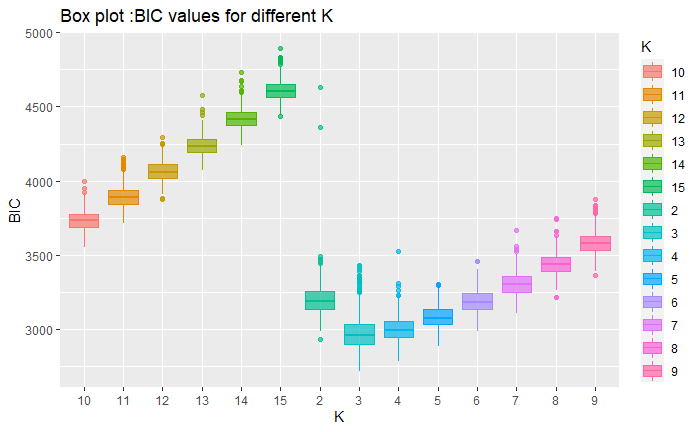

```r
df_graph %>% ggplot(aes(x=K, y=BIC, colour = K,fill=K))+geom_boxplot(alpha=0.7) + labs(title = "Box plot :BIC values for different K")
```

# Box plot for smaller range of K= [2..9]

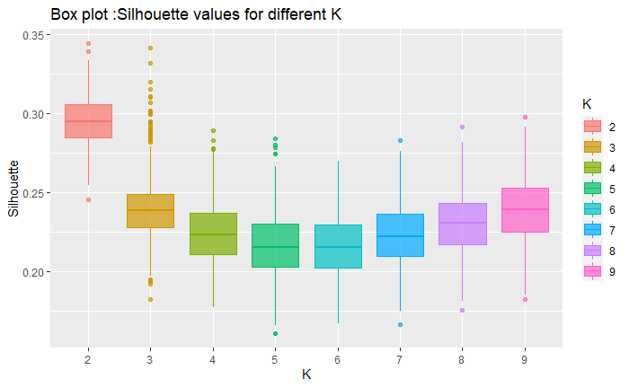

```r
df_graph %>% filter(between(K,2,9)) %>% ggplot(aes(x=K, y=Silhouette, colour = K,fill=K))+geom_boxplot(alpha=0.7) + labs(title = "Box plot :Silhouette values for different K")
```

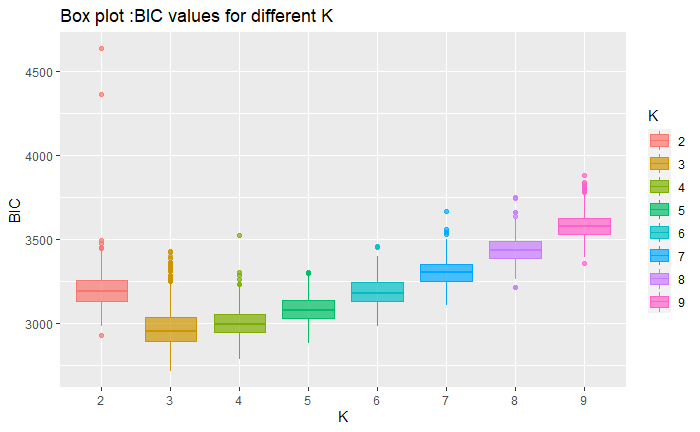

```r
df_graph %>% filter(between(K,2,9)) %>% ggplot(aes(x=K, y=BIC, colour = K,fill=K))+geom_boxplot(alpha=0.7) + labs(title = "Box plot :BIC values for different K")
```

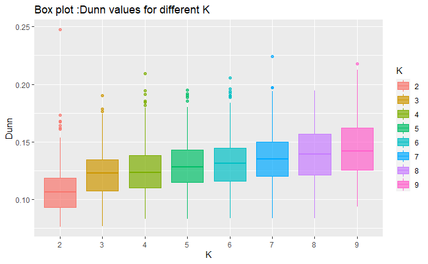

```r
# df_graph %>% filter(between(K,3,10))%>%
df_graph %>% filter(between(K,2,9)) %>% ggplot(aes(x=K, y=Dunn, colour = K,fill=K))+geom_boxplot(alpha=0.7) + labs(title = "Box plot :Dunn values for different K")
```

```r
NA
NA
```

**References**

Ansari, Zahid, M F Azeem, Waseem Ahmed, and A Vinaya Babu. 2011. “Quantitative Evaluation of Performance and Validity Indices for Clustering the Web Navigational Sessions.”

Murphy, Kevin P. 2012. “Machine Learning a Probabilistic Perspective.”

P, Bickel, Diggle P, Fienberg S, Gather U, Olkin I, and Zeger S. 2017. “Springer Series in Statistics.”